# Risk Factor Analysis

## Outcome Variable

**Outcome Variable:** ever_stunted

## Predictor Variables

**Intervention Variable:** gagebrth

**Adjustment Set:**

unadjusted

## Stratifying Variables

The analysis was stratified on these variable(s):

- agecat
- studyid
- country

## Data Summary

| agecat | studyid | country | gagebrth | ever_stunted | n_cell | n |
| --- | --- | --- | --- | --- | --- | --- |
| 0-24 months (no birth st.) | ki1000108-CMC-V-BCS-2002 | INDIA | Full or late term | 0 | 18 | 278 |
| 0-24 months (no birth st.) | ki1000108-CMC-V-BCS-2002 | INDIA | Full or late term | 1 | 164 | 278 |
| 0-24 months (no birth st.) | ki1000108-CMC-V-BCS-2002 | INDIA | Preterm | 0 | 3 | 278 |
| 0-24 months (no birth st.) | ki1000108-CMC-V-BCS-2002 | INDIA | Preterm | 1 | 30 | 278 |
| 0-24 months (no birth st.) | ki1000108-CMC-V-BCS-2002 | INDIA | Early term | 0 | 7 | 278 |
| 0-24 months (no birth st.) | ki1000108-CMC-V-BCS-2002 | INDIA | Early term | 1 | 56 | 278 |
| 0-24 months (no birth st.) | ki1000108-IRC | INDIA | Full or late term | 0 | 95 | 341 |
| 0-24 months (no birth st.) | ki1000108-IRC | INDIA | Full or late term | 1 | 126 | 341 |
| 0-24 months (no birth st.) | ki1000108-IRC | INDIA | Preterm | 0 | 9 | 341 |
| 0-24 months (no birth st.) | ki1000108-IRC | INDIA | Preterm | 1 | 23 | 341 |
| 0-24 months (no birth st.) | ki1000108-IRC | INDIA | Early term | 0 | 34 | 341 |
| 0-24 months (no birth st.) | ki1000108-IRC | INDIA | Early term | 1 | 54 | 341 |
| 0-24 months (no birth st.) | ki1000109-EE | PAKISTAN | Full or late term | 0 | 3 | 249 |
| 0-24 months (no birth st.) | ki1000109-EE | PAKISTAN | Full or late term | 1 | 15 | 249 |
| 0-24 months (no birth st.) | ki1000109-EE | PAKISTAN | Preterm | 0 | 14 | 249 |
| 0-24 months (no birth st.) | ki1000109-EE | PAKISTAN | Preterm | 1 | 146 | 249 |
| 0-24 months (no birth st.) | ki1000109-EE | PAKISTAN | Early term | 0 | 16 | 249 |
| 0-24 months (no birth st.) | ki1000109-EE | PAKISTAN | Early term | 1 | 55 | 249 |
| 0-24 months (no birth st.) | ki1000304b-SAS-CompFeed | INDIA | Full or late term | 0 | 8 | 1081 |
| 0-24 months (no birth st.) | ki1000304b-SAS-CompFeed | INDIA | Full or late term | 1 | 16 | 1081 |
| 0-24 months (no birth st.) | ki1000304b-SAS-CompFeed | INDIA | Preterm | 0 | 422 | 1081 |
| 0-24 months (no birth st.) | ki1000304b-SAS-CompFeed | INDIA | Preterm | 1 | 550 | 1081 |
| 0-24 months (no birth st.) | ki1000304b-SAS-CompFeed | INDIA | Early term | 0 | 35 | 1081 |
| 0-24 months (no birth st.) | ki1000304b-SAS-CompFeed | INDIA | Early term | 1 | 50 | 1081 |
| 0-24 months (no birth st.) | ki1017093c-NIH-Crypto | BANGLADESH | Full or late term | 0 | 105 | 653 |
| 0-24 months (no birth st.) | ki1017093c-NIH-Crypto | BANGLADESH | Full or late term | 1 | 51 | 653 |
| 0-24 months (no birth st.) | ki1017093c-NIH-Crypto | BANGLADESH | Preterm | 0 | 110 | 653 |
| 0-24 months (no birth st.) | ki1017093c-NIH-Crypto | BANGLADESH | Preterm | 1 | 89 | 653 |
| 0-24 months (no birth st.) | ki1017093c-NIH-Crypto | BANGLADESH | Early term | 0 | 181 | 653 |
| 0-24 months (no birth st.) | ki1017093c-NIH-Crypto | BANGLADESH | Early term | 1 | 117 | 653 |

[output cut: 186 more lines]

The following strata were considered:

- agecat: 0-24 months (no birth st.), studyid: ki1000108-CMC-V-BCS-2002, country: INDIA
- agecat: 0-24 months (no birth st.), studyid: ki1000108-IRC, country: INDIA
- agecat: 0-24 months (no birth st.), studyid: ki1000109-EE, country: PAKISTAN
- agecat: 0-24 months (no birth st.), studyid: ki1000304b-SAS-CompFeed, country: INDIA
- agecat: 0-24 months (no birth st.), studyid: ki1017093c-NIH-Crypto, country: BANGLADESH
- agecat: 0-24 months (no birth st.), studyid: ki1066203-TanzaniaChild2, country: TANZANIA, UNITED REPUBLIC OF
- agecat: 0-24 months (no birth st.), studyid: ki1101329-Keneba, country: GAMBIA
- agecat: 0-24 months (no birth st.), studyid: ki1119695-PROBIT, country: BELARUS
- agecat: 0-24 months (no birth st.), studyid: ki1135781-COHORTS, country: GUATEMALA
- agecat: 0-24 months (no birth st.), studyid: ki1135781-COHORTS, country: INDIA
- agecat: 0-24 months (no birth st.), studyid: ki1135781-COHORTS, country: PHILIPPINES
- agecat: 0-24 months (no birth st.), studyid: kiGH5241-JiVitA-3, country: BANGLADESH
- agecat: 0-6 months (no birth st.), studyid: ki1000108-CMC-V-BCS-2002, country: INDIA
- agecat: 0-6 months (no birth st.), studyid: ki1000108-IRC, country: INDIA
- agecat: 0-6 months (no birth st.), studyid: ki1000109-EE, country: PAKISTAN
- agecat: 0-6 months (no birth st.), studyid: ki1000304b-SAS-CompFeed, country: INDIA
- agecat: 0-6 months (no birth st.), studyid: ki1017093c-NIH-Crypto, country: BANGLADESH
- agecat: 0-6 months (no birth st.), studyid: ki1066203-TanzaniaChild2, country: TANZANIA, UNITED REPUBLIC OF
- agecat: 0-6 months (no birth st.), studyid: ki1101329-Keneba, country: GAMBIA
- agecat: 0-6 months (no birth st.), studyid: ki1119695-PROBIT, country: BELARUS
- agecat: 0-6 months (no birth st.), studyid: ki1135781-COHORTS, country: GUATEMALA
- agecat: 0-6 months (no birth st.), studyid: ki1135781-COHORTS, country: INDIA
- agecat: 0-6 months (no birth st.), studyid: ki1135781-COHORTS, country: PHILIPPINES
- agecat: 0-6 months (no birth st.), studyid: kiGH5241-JiVitA-3, country: BANGLADESH
- agecat: 6-24 months, studyid: ki1000108-CMC-V-BCS-2002, country: INDIA
- agecat: 6-24 months, studyid: ki1000108-IRC, country: INDIA
- agecat: 6-24 months, studyid: ki1000109-EE, country: PAKISTAN
- agecat: 6-24 months, studyid: ki1000304b-SAS-CompFeed, country: INDIA
- agecat: 6-24 months, studyid: ki1017093c-NIH-Crypto, country: BANGLADESH
- agecat: 6-24 months, studyid: ki1066203-TanzaniaChild2, country: TANZANIA, UNITED REPUBLIC OF
- agecat: 6-24 months, studyid: ki1101329-Keneba, country: GAMBIA
- agecat: 6-24 months, studyid: ki1119695-PROBIT, country: BELARUS
- agecat: 6-24 months, studyid: ki1135781-COHORTS, country: GUATEMALA
- agecat: 6-24 months, studyid: ki1135781-COHORTS, country: INDIA
- agecat: 6-24 months, studyid: ki1135781-COHORTS, country: PHILIPPINES
- agecat: 6-24 months, studyid: kiGH5241-JiVitA-3, country: BANGLADESH

### Dropped Strata

Some strata were dropped due to rare outcomes:

- agecat: 0-24 months (no birth st.), studyid: ki1000108-CMC-V-BCS-2002, country: INDIA
- agecat: 0-24 months (no birth st.), studyid: ki1000109-EE, country: PAKISTAN
- agecat: 0-6 months (no birth st.), studyid: ki1000304b-SAS-CompFeed, country: INDIA
- agecat: 6-24 months, studyid: ki1000108-CMC-V-BCS-2002, country: INDIA
- agecat: 6-24 months, studyid: ki1000109-EE, country: PAKISTAN

## Methods Detail

We’re interested in the causal parameters $E[Y_a]$ for all values of $a \in \mathcal{A}$. These parameters represent the mean outcome if, possibly contrary to fact, we intervened to set all units to have $A=a$. Under the randomization and positivity assumptions, these are identified by the statistical parameters $\psi_a=E_W[E_{Y|A,W}(Y|A=a,W)]$. In addition, we’re interested in the mean of $Y$, $E[Y]$ under no intervention (the observed mean). We will estimate these parameters by using SuperLearner to fit the relevant likelihood factors – $E_{Y|A,W}(Y|A=a,W)$ and $p(A=a|W)$, and then updating our likelihood fit using a joint TMLE.

For unadjusted analyses ($W=\{\}$), initial likelihoods were estimated using Lrnr_glm to estimate the simple $E(Y|A)$ and Lrnr_mean to estimate $p(A)$. For adjusted analyses, a small library containing Lrnr_glmnet, Lrnr_xgboost, and Lrnr_mean was used.

Having estimated these parameters, we will then use the delta method to estimate relative risks and attributable risks relative to a prespecified baseline level of $A$.

# Results Detail

## Results Plots

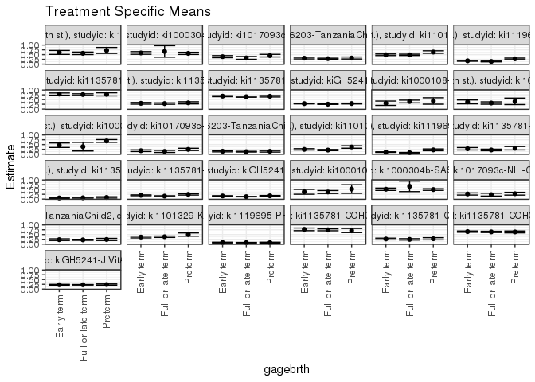

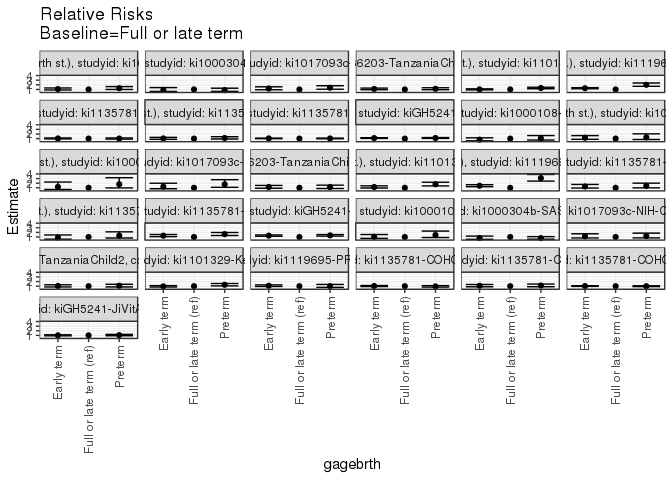

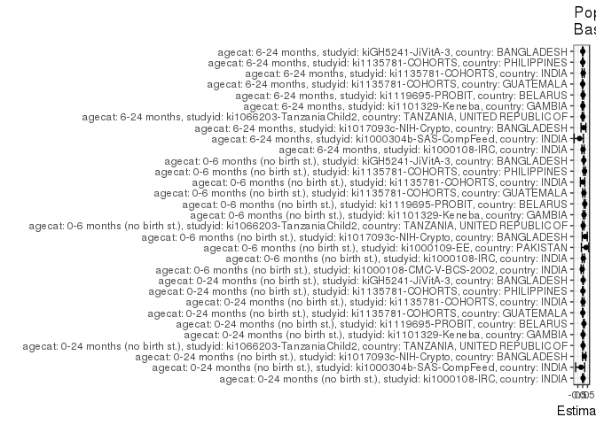

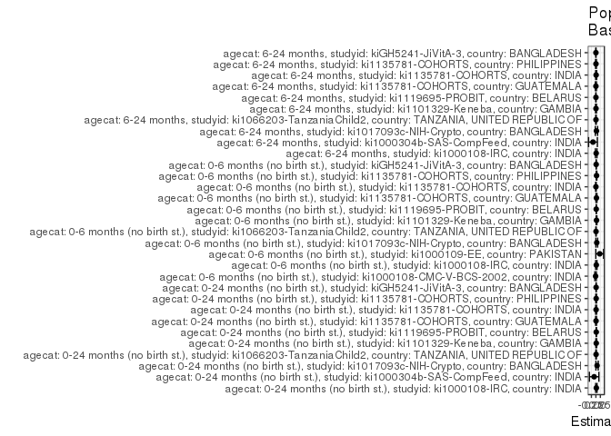

## Results Table

### Parameter: TSM

| agecat | studyid | country | intervention_level | baseline_level | estimate | ci_lower | ci_upper |
| --- | --- | --- | --- | --- | --- | --- | --- |
| 0-24 months (no birth st.) | ki1000108-IRC | INDIA | Full or late term | NA | 0.5701357 | 0.5047709 | 0.6355006 |
| 0-24 months (no birth st.) | ki1000108-IRC | INDIA | Preterm | NA | 0.7187500 | 0.5627423 | 0.8747577 |
| 0-24 months (no birth st.) | ki1000108-IRC | INDIA | Early term | NA | 0.6136364 | 0.5117542 | 0.7155185 |
| 0-24 months (no birth st.) | ki1000304b-SAS-CompFeed | INDIA | Full or late term | NA | 0.6666667 | 0.3663101 | 0.9670232 |
| 0-24 months (no birth st.) | ki1000304b-SAS-CompFeed | INDIA | Preterm | NA | 0.5658436 | 0.5093009 | 0.6223863 |
| 0-24 months (no birth st.) | ki1000304b-SAS-CompFeed | INDIA | Early term | NA | 0.5882353 | 0.5185374 | 0.6579332 |
| 0-24 months (no birth st.) | ki1017093c-NIH-Crypto | BANGLADESH | Full or late term | NA | 0.3269231 | 0.2532560 | 0.4005902 |
| 0-24 months (no birth st.) | ki1017093c-NIH-Crypto | BANGLADESH | Preterm | NA | 0.4472362 | 0.3781020 | 0.5163703 |
| 0-24 months (no birth st.) | ki1017093c-NIH-Crypto | BANGLADESH | Early term | NA | 0.3926174 | 0.3371308 | 0.4481041 |
| 0-24 months (no birth st.) | ki1066203-TanzaniaChild2 | TANZANIA, UNITED REPUBLIC OF | Full or late term | NA | 0.2864701 | 0.2621023 | 0.3108380 |
| 0-24 months (no birth st.) | ki1066203-TanzaniaChild2 | TANZANIA, UNITED REPUBLIC OF | Preterm | NA | 0.3222591 | 0.2694508 | 0.3750675 |
| 0-24 months (no birth st.) | ki1066203-TanzaniaChild2 | TANZANIA, UNITED REPUBLIC OF | Early term | NA | 0.3144654 | 0.2727887 | 0.3561421 |
| 0-24 months (no birth st.) | ki1101329-Keneba | GAMBIA | Full or late term | NA | 0.4882280 | 0.4537297 | 0.5227264 |
| 0-24 months (no birth st.) | ki1101329-Keneba | GAMBIA | Preterm | NA | 0.6338028 | 0.5690840 | 0.6985216 |
| 0-24 months (no birth st.) | ki1101329-Keneba | GAMBIA | Early term | NA | 0.4919786 | 0.4505960 | 0.5333612 |
| 0-24 months (no birth st.) | ki1119695-PROBIT | BELARUS | Full or late term | NA | 0.1390960 | 0.1196695 | 0.1585225 |
| 0-24 months (no birth st.) | ki1119695-PROBIT | BELARUS | Preterm | NA | 0.2783688 | 0.2400434 | 0.3166942 |
| 0-24 months (no birth st.) | ki1119695-PROBIT | BELARUS | Early term | NA | 0.1743482 | 0.1522350 | 0.1964613 |
| 0-24 months (no birth st.) | ki1135781-COHORTS | GUATEMALA | Full or late term | NA | 0.7632242 | 0.7213775 | 0.8050708 |
| 0-24 months (no birth st.) | ki1135781-COHORTS | GUATEMALA | Preterm | NA | 0.7745098 | 0.6933505 | 0.8556691 |
| 0-24 months (no birth st.) | ki1135781-COHORTS | GUATEMALA | Early term | NA | 0.7897436 | 0.7325086 | 0.8469786 |
| 0-24 months (no birth st.) | ki1135781-COHORTS | INDIA | Full or late term | NA | 0.2882883 | 0.2505882 | 0.3259884 |
| 0-24 months (no birth st.) | ki1135781-COHORTS | INDIA | Preterm | NA | 0.3271375 | 0.2710488 | 0.3832263 |
| 0-24 months (no birth st.) | ki1135781-COHORTS | INDIA | Early term | NA | 0.2995169 | 0.2553769 | 0.3436570 |
| 0-24 months (no birth st.) | ki1135781-COHORTS | PHILIPPINES | Full or late term | NA | 0.6504425 | 0.6226358 | 0.6782491 |
| 0-24 months (no birth st.) | ki1135781-COHORTS | PHILIPPINES | Preterm | NA | 0.6725664 | 0.6338647 | 0.7112680 |
| 0-24 months (no birth st.) | ki1135781-COHORTS | PHILIPPINES | Early term | NA | 0.6785404 | 0.6515544 | 0.7055264 |
| 0-24 months (no birth st.) | kiGH5241-JiVitA-3 | BANGLADESH | Full or late term | NA | 0.2563625 | 0.2453661 | 0.2673590 |
| 0-24 months (no birth st.) | kiGH5241-JiVitA-3 | BANGLADESH | Preterm | NA | 0.2892057 | 0.2673755 | 0.3110359 |
| 0-24 months (no birth st.) | kiGH5241-JiVitA-3 | BANGLADESH | Early term | NA | 0.2859938 | 0.2698539 | 0.3021338 |

[output cut: 63 more lines]

### Parameter: E(Y)

| agecat | studyid | country | intervention_level | baseline_level | estimate | ci_lower | ci_upper |
| --- | --- | --- | --- | --- | --- | --- | --- |
| 0-24 months (no birth st.) | ki1000108-IRC | INDIA | NA | NA | 0.5953079 | 0.5431354 | 0.6474804 |
| 0-24 months (no birth st.) | ki1000304b-SAS-CompFeed | INDIA | NA | NA | 0.5698427 | 0.5147261 | 0.6249593 |
| 0-24 months (no birth st.) | ki1017093c-NIH-Crypto | BANGLADESH | NA | NA | 0.3935681 | 0.3560687 | 0.4310676 |
| 0-24 months (no birth st.) | ki1066203-TanzaniaChild2 | TANZANIA, UNITED REPUBLIC OF | NA | NA | 0.2979534 | 0.2783922 | 0.3175146 |
| 0-24 months (no birth st.) | ki1101329-Keneba | GAMBIA | NA | NA | 0.5091714 | 0.4845214 | 0.5338214 |
| 0-24 months (no birth st.) | ki1119695-PROBIT | BELARUS | NA | NA | 0.1597778 | 0.1408215 | 0.1787342 |
| 0-24 months (no birth st.) | ki1135781-COHORTS | GUATEMALA | NA | NA | 0.7723343 | 0.7411143 | 0.8035543 |
| 0-24 months (no birth st.) | ki1135781-COHORTS | INDIA | NA | NA | 0.3004847 | 0.2749357 | 0.3260336 |
| 0-24 months (no birth st.) | ki1135781-COHORTS | PHILIPPINES | NA | NA | 0.6661982 | 0.6488700 | 0.6835264 |
| 0-24 months (no birth st.) | kiGH5241-JiVitA-3 | BANGLADESH | NA | NA | 0.2689026 | 0.2600803 | 0.2777249 |
| 0-6 months (no birth st.) | ki1000108-CMC-V-BCS-2002 | INDIA | NA | NA | 0.3795620 | 0.3219972 | 0.4371269 |
| 0-6 months (no birth st.) | ki1000108-IRC | INDIA | NA | NA | 0.3401760 | 0.2898173 | 0.3905347 |
| 0-6 months (no birth st.) | ki1000109-EE | PAKISTAN | NA | NA | 0.6024096 | 0.5415000 | 0.6633193 |
| 0-6 months (no birth st.) | ki1017093c-NIH-Crypto | BANGLADESH | NA | NA | 0.1898928 | 0.1597870 | 0.2199986 |
| 0-6 months (no birth st.) | ki1066203-TanzaniaChild2 | TANZANIA, UNITED REPUBLIC OF | NA | NA | 0.1346978 | 0.1200961 | 0.1492994 |
| 0-6 months (no birth st.) | ki1101329-Keneba | GAMBIA | NA | NA | 0.2466667 | 0.2248446 | 0.2684887 |
| 0-6 months (no birth st.) | ki1119695-PROBIT | BELARUS | NA | NA | 0.0912784 | 0.0781588 | 0.1043979 |
| 0-6 months (no birth st.) | ki1135781-COHORTS | GUATEMALA | NA | NA | 0.2481315 | 0.2153770 | 0.2808861 |
| 0-6 months (no birth st.) | ki1135781-COHORTS | INDIA | NA | NA | 0.0687398 | 0.0545482 | 0.0829313 |
| 0-6 months (no birth st.) | ki1135781-COHORTS | PHILIPPINES | NA | NA | 0.1897400 | 0.1753322 | 0.2041478 |
| 0-6 months (no birth st.) | kiGH5241-JiVitA-3 | BANGLADESH | NA | NA | 0.1424158 | 0.1357405 | 0.1490910 |
| 6-24 months | ki1000108-IRC | INDIA | NA | NA | 0.3866667 | 0.3228931 | 0.4504402 |
| 6-24 months | ki1000304b-SAS-CompFeed | INDIA | NA | NA | 0.5049505 | 0.4617314 | 0.5481695 |
| 6-24 months | ki1017093c-NIH-Crypto | BANGLADESH | NA | NA | 0.2628458 | 0.2244546 | 0.3012371 |
| 6-24 months | ki1066203-TanzaniaChild2 | TANZANIA, UNITED REPUBLIC OF | NA | NA | 0.2274536 | 0.2062895 | 0.2486177 |
| 6-24 months | ki1101329-Keneba | GAMBIA | NA | NA | 0.3917012 | 0.3641291 | 0.4192734 |
| 6-24 months | ki1119695-PROBIT | BELARUS | NA | NA | 0.0768510 | 0.0628857 | 0.0908164 |
| 6-24 months | ki1135781-COHORTS | GUATEMALA | NA | NA | 0.7490347 | 0.7116615 | 0.7864080 |
| 6-24 months | ki1135781-COHORTS | INDIA | NA | NA | 0.2598214 | 0.2341270 | 0.2855158 |
| 6-24 months | ki1135781-COHORTS | PHILIPPINES | NA | NA | 0.6444867 | 0.6240287 | 0.6649447 |
| 6-24 months | kiGH5241-JiVitA-3 | BANGLADESH | NA | NA | 0.2266404 | 0.2153534 | 0.2379275 |

### Parameter: RR

| agecat | studyid | country | intervention_level | baseline_level | estimate | ci_lower | ci_upper |
| --- | --- | --- | --- | --- | --- | --- | --- |
| 0-24 months (no birth st.) | ki1000108-IRC | INDIA | Full or late term | Full or late term | 1.0000000 | 1.0000000 | 1.000000 |
| 0-24 months (no birth st.) | ki1000108-IRC | INDIA | Preterm | Full or late term | 1.2606647 | 0.9862620 | 1.611413 |
| 0-24 months (no birth st.) | ki1000108-IRC | INDIA | Early term | Full or late term | 1.0762987 | 0.8796426 | 1.316920 |
| 0-24 months (no birth st.) | ki1000304b-SAS-CompFeed | INDIA | Full or late term | Full or late term | 1.0000000 | 1.0000000 | 1.000000 |
| 0-24 months (no birth st.) | ki1000304b-SAS-CompFeed | INDIA | Preterm | Full or late term | 0.8487654 | 0.5693739 | 1.265254 |
| 0-24 months (no birth st.) | ki1000304b-SAS-CompFeed | INDIA | Early term | Full or late term | 0.8823529 | 0.5595601 | 1.391355 |
| 0-24 months (no birth st.) | ki1017093c-NIH-Crypto | BANGLADESH | Full or late term | Full or late term | 1.0000000 | 1.0000000 | 1.000000 |
| 0-24 months (no birth st.) | ki1017093c-NIH-Crypto | BANGLADESH | Preterm | Full or late term | 1.3680166 | 1.0409169 | 1.797905 |
| 0-24 months (no birth st.) | ki1017093c-NIH-Crypto | BANGLADESH | Early term | Full or late term | 1.2009475 | 0.9204661 | 1.566896 |
| 0-24 months (no birth st.) | ki1066203-TanzaniaChild2 | TANZANIA, UNITED REPUBLIC OF | Full or late term | Full or late term | 1.0000000 | 1.0000000 | 1.000000 |
| 0-24 months (no birth st.) | ki1066203-TanzaniaChild2 | TANZANIA, UNITED REPUBLIC OF | Preterm | Full or late term | 1.1249310 | 0.9352796 | 1.353039 |
| 0-24 months (no birth st.) | ki1066203-TanzaniaChild2 | TANZANIA, UNITED REPUBLIC OF | Early term | Full or late term | 1.0977249 | 0.9377785 | 1.284952 |
| 0-24 months (no birth st.) | ki1101329-Keneba | GAMBIA | Full or late term | Full or late term | 1.0000000 | 1.0000000 | 1.000000 |
| 0-24 months (no birth st.) | ki1101329-Keneba | GAMBIA | Preterm | Full or late term | 1.2981697 | 1.1465750 | 1.469808 |
| 0-24 months (no birth st.) | ki1101329-Keneba | GAMBIA | Early term | Full or late term | 1.0076821 | 0.9028467 | 1.124691 |
| 0-24 months (no birth st.) | ki1119695-PROBIT | BELARUS | Full or late term | Full or late term | 1.0000000 | 1.0000000 | 1.000000 |
| 0-24 months (no birth st.) | ki1119695-PROBIT | BELARUS | Preterm | Full or late term | 2.0012711 | 1.6754526 | 2.390450 |
| 0-24 months (no birth st.) | ki1119695-PROBIT | BELARUS | Early term | Full or late term | 1.2534378 | 1.1367670 | 1.382083 |
| 0-24 months (no birth st.) | ki1135781-COHORTS | GUATEMALA | Full or late term | Full or late term | 1.0000000 | 1.0000000 | 1.000000 |
| 0-24 months (no birth st.) | ki1135781-COHORTS | GUATEMALA | Preterm | Full or late term | 1.0147868 | 0.9015976 | 1.142186 |
| 0-24 months (no birth st.) | ki1135781-COHORTS | GUATEMALA | Early term | Full or late term | 1.0347466 | 0.9448587 | 1.133186 |
| 0-24 months (no birth st.) | ki1135781-COHORTS | INDIA | Full or late term | Full or late term | 1.0000000 | 1.0000000 | 1.000000 |
| 0-24 months (no birth st.) | ki1135781-COHORTS | INDIA | Preterm | Full or late term | 1.1347584 | 0.9146506 | 1.407834 |
| 0-24 months (no birth st.) | ki1135781-COHORTS | INDIA | Early term | Full or late term | 1.0389493 | 0.8531526 | 1.265208 |
| 0-24 months (no birth st.) | ki1135781-COHORTS | PHILIPPINES | Full or late term | Full or late term | 1.0000000 | 1.0000000 | 1.000000 |
| 0-24 months (no birth st.) | ki1135781-COHORTS | PHILIPPINES | Preterm | Full or late term | 1.0340136 | 0.9624842 | 1.110859 |
| 0-24 months (no birth st.) | ki1135781-COHORTS | PHILIPPINES | Early term | Full or late term | 1.0431982 | 0.9840309 | 1.105923 |
| 0-24 months (no birth st.) | kiGH5241-JiVitA-3 | BANGLADESH | Full or late term | Full or late term | 1.0000000 | 1.0000000 | 1.000000 |
| 0-24 months (no birth st.) | kiGH5241-JiVitA-3 | BANGLADESH | Preterm | Full or late term | 1.1281123 | 1.0371746 | 1.227023 |
| 0-24 months (no birth st.) | kiGH5241-JiVitA-3 | BANGLADESH | Early term | Full or late term | 1.1155838 | 1.0418125 | 1.194579 |

[output cut: 63 more lines]

### Parameter: PAR

| agecat | studyid | country | intervention_level | baseline_level | estimate | ci_lower | ci_upper |
| --- | --- | --- | --- | --- | --- | --- | --- |
| 0-24 months (no birth st.) | ki1000108-IRC | INDIA | Full or late term | NA | 0.0251722 | -0.0129918 | 0.0633362 |
| 0-24 months (no birth st.) | ki1000304b-SAS-CompFeed | INDIA | Full or late term | NA | -0.0968239 | -0.3620298 | 0.1683819 |
| 0-24 months (no birth st.) | ki1017093c-NIH-Crypto | BANGLADESH | Full or late term | NA | 0.0666451 | 0.0015287 | 0.1317614 |
| 0-24 months (no birth st.) | ki1066203-TanzaniaChild2 | TANZANIA, UNITED REPUBLIC OF | Full or late term | NA | 0.0114832 | -0.0036367 | 0.0266031 |
| 0-24 months (no birth st.) | ki1101329-Keneba | GAMBIA | Full or late term | NA | 0.0209434 | -0.0031974 | 0.0450842 |
| 0-24 months (no birth st.) | ki1119695-PROBIT | BELARUS | Full or late term | NA | 0.0206818 | 0.0136955 | 0.0276681 |
| 0-24 months (no birth st.) | ki1135781-COHORTS | GUATEMALA | Full or late term | NA | 0.0091101 | -0.0177667 | 0.0359869 |
| 0-24 months (no birth st.) | ki1135781-COHORTS | INDIA | Full or late term | NA | 0.0121964 | -0.0160826 | 0.0404753 |
| 0-24 months (no birth st.) | ki1135781-COHORTS | PHILIPPINES | Full or late term | NA | 0.0157557 | -0.0056796 | 0.0371910 |
| 0-24 months (no birth st.) | kiGH5241-JiVitA-3 | BANGLADESH | Full or late term | NA | 0.0125401 | 0.0059129 | 0.0191674 |
| 0-6 months (no birth st.) | ki1000108-CMC-V-BCS-2002 | INDIA | Full or late term | NA | -0.0170860 | -0.0587204 | 0.0245484 |
| 0-6 months (no birth st.) | ki1000108-IRC | INDIA | Full or late term | NA | 0.0234339 | -0.0142295 | 0.0610972 |
| 0-6 months (no birth st.) | ki1000109-EE | PAKISTAN | Full or late term | NA | 0.2135207 | -0.0038980 | 0.4309395 |
| 0-6 months (no birth st.) | ki1017093c-NIH-Crypto | BANGLADESH | Full or late term | NA | 0.0488672 | -0.0007964 | 0.0985308 |
| 0-6 months (no birth st.) | ki1066203-TanzaniaChild2 | TANZANIA, UNITED REPUBLIC OF | Full or late term | NA | 0.0077136 | -0.0036737 | 0.0191009 |
| 0-6 months (no birth st.) | ki1101329-Keneba | GAMBIA | Full or late term | NA | 0.0350265 | 0.0133604 | 0.0566925 |
| 0-6 months (no birth st.) | ki1119695-PROBIT | BELARUS | Full or late term | NA | 0.0195086 | 0.0138541 | 0.0251631 |
| 0-6 months (no birth st.) | ki1135781-COHORTS | GUATEMALA | Full or late term | NA | 0.0312003 | 0.0020795 | 0.0603212 |
| 0-6 months (no birth st.) | ki1135781-COHORTS | INDIA | Full or late term | NA | 0.0013445 | -0.0143419 | 0.0170309 |
| 0-6 months (no birth st.) | ki1135781-COHORTS | PHILIPPINES | Full or late term | NA | 0.0366426 | 0.0193691 | 0.0539162 |
| 0-6 months (no birth st.) | kiGH5241-JiVitA-3 | BANGLADESH | Full or late term | NA | 0.0161431 | 0.0106718 | 0.0216144 |
| 6-24 months | ki1000108-IRC | INDIA | Full or late term | NA | 0.0158057 | -0.0292126 | 0.0608240 |
| 6-24 months | ki1000304b-SAS-CompFeed | INDIA | Full or late term | NA | -0.1617162 | -0.4070183 | 0.0835859 |
| 6-24 months | ki1017093c-NIH-Crypto | BANGLADESH | Full or late term | NA | 0.0308458 | -0.0343436 | 0.0960353 |
| 6-24 months | ki1066203-TanzaniaChild2 | TANZANIA, UNITED REPUBLIC OF | Full or late term | NA | 0.0051143 | -0.0112195 | 0.0214480 |
| 6-24 months | ki1101329-Keneba | GAMBIA | Full or late term | NA | 0.0063658 | -0.0195078 | 0.0322395 |
| 6-24 months | ki1119695-PROBIT | BELARUS | Full or late term | NA | 0.0029519 | -0.0028848 | 0.0087886 |
| 6-24 months | ki1135781-COHORTS | GUATEMALA | Full or late term | NA | 0.0014938 | -0.0297117 | 0.0326992 |
| 6-24 months | ki1135781-COHORTS | INDIA | Full or late term | NA | 0.0142769 | -0.0139849 | 0.0425387 |
| 6-24 months | ki1135781-COHORTS | PHILIPPINES | Full or late term | NA | 0.0051238 | -0.0190490 | 0.0292965 |
| 6-24 months | kiGH5241-JiVitA-3 | BANGLADESH | Full or late term | NA | 0.0019888 | -0.0063843 | 0.0103619 |

### Parameter: PAF

| agecat | studyid | country | intervention_level | baseline_level | estimate | ci_lower | ci_upper |
| --- | --- | --- | --- | --- | --- | --- | --- |
| 0-24 months (no birth st.) | ki1000108-IRC | INDIA | Full or late term | NA | 0.0422843 | -0.0242259 | 0.1044755 |
| 0-24 months (no birth st.) | ki1000304b-SAS-CompFeed | INDIA | Full or late term | NA | -0.1699134 | -0.7277410 | 0.2078110 |
| 0-24 months (no birth st.) | ki1017093c-NIH-Crypto | BANGLADESH | Full or late term | NA | 0.1693355 | -0.0138187 | 0.3194015 |
| 0-24 months (no birth st.) | ki1066203-TanzaniaChild2 | TANZANIA, UNITED REPUBLIC OF | Full or late term | NA | 0.0385403 | -0.0135563 | 0.0879592 |
| 0-24 months (no birth st.) | ki1101329-Keneba | GAMBIA | Full or late term | NA | 0.0411323 | -0.0075148 | 0.0874306 |
| 0-24 months (no birth st.) | ki1119695-PROBIT | BELARUS | Full or late term | NA | 0.1294411 | 0.0836484 | 0.1729454 |
| 0-24 months (no birth st.) | ki1135781-COHORTS | GUATEMALA | Full or late term | NA | 0.0117956 | -0.0236432 | 0.0460074 |
| 0-24 months (no birth st.) | ki1135781-COHORTS | INDIA | Full or late term | NA | 0.0405890 | -0.0582805 | 0.1302216 |
| 0-24 months (no birth st.) | ki1135781-COHORTS | PHILIPPINES | Full or late term | NA | 0.0236502 | -0.0090791 | 0.0553178 |
| 0-24 months (no birth st.) | kiGH5241-JiVitA-3 | BANGLADESH | Full or late term | NA | 0.0466344 | 0.0216300 | 0.0709997 |
| 0-6 months (no birth st.) | ki1000108-CMC-V-BCS-2002 | INDIA | Full or late term | NA | -0.0450150 | -0.1607351 | 0.0591683 |
| 0-6 months (no birth st.) | ki1000108-IRC | INDIA | Full or late term | NA | 0.0688875 | -0.0486600 | 0.1732588 |
| 0-6 months (no birth st.) | ki1000109-EE | PAKISTAN | Full or late term | NA | 0.3544444 | -0.1320864 | 0.6318815 |
| 0-6 months (no birth st.) | ki1017093c-NIH-Crypto | BANGLADESH | Full or late term | NA | 0.2573408 | -0.0532049 | 0.4763196 |
| 0-6 months (no birth st.) | ki1066203-TanzaniaChild2 | TANZANIA, UNITED REPUBLIC OF | Full or late term | NA | 0.0572663 | -0.0310035 | 0.1379788 |
| 0-6 months (no birth st.) | ki1101329-Keneba | GAMBIA | Full or late term | NA | 0.1419991 | 0.0499475 | 0.2251318 |
| 0-6 months (no birth st.) | ki1119695-PROBIT | BELARUS | Full or late term | NA | 0.2137264 | 0.1459215 | 0.2761483 |
| 0-6 months (no birth st.) | ki1135781-COHORTS | GUATEMALA | Full or late term | NA | 0.1257411 | 0.0007075 | 0.2351302 |
| 0-6 months (no birth st.) | ki1135781-COHORTS | INDIA | Full or late term | NA | 0.0195594 | -0.2373454 | 0.2231241 |
| 0-6 months (no birth st.) | ki1135781-COHORTS | PHILIPPINES | Full or late term | NA | 0.1931203 | 0.0975734 | 0.2785509 |
| 0-6 months (no birth st.) | kiGH5241-JiVitA-3 | BANGLADESH | Full or late term | NA | 0.1133520 | 0.0742009 | 0.1508474 |
| 6-24 months | ki1000108-IRC | INDIA | Full or late term | NA | 0.0408769 | -0.0829571 | 0.1505508 |
| 6-24 months | ki1000304b-SAS-CompFeed | INDIA | Full or late term | NA | -0.3202614 | -0.8838898 | 0.0747388 |
| 6-24 months | ki1017093c-NIH-Crypto | BANGLADESH | Full or late term | NA | 0.1173534 | -0.1687207 | 0.3334036 |
| 6-24 months | ki1066203-TanzaniaChild2 | TANZANIA, UNITED REPUBLIC OF | Full or late term | NA | 0.0224849 | -0.0520160 | 0.0917099 |
| 6-24 months | ki1101329-Keneba | GAMBIA | Full or late term | NA | 0.0162518 | -0.0520738 | 0.0801400 |
| 6-24 months | ki1119695-PROBIT | BELARUS | Full or late term | NA | 0.0384104 | -0.0379816 | 0.1091801 |
| 6-24 months | ki1135781-COHORTS | GUATEMALA | Full or late term | NA | 0.0019943 | -0.0405490 | 0.0427981 |
| 6-24 months | ki1135781-COHORTS | INDIA | Full or late term | NA | 0.0549488 | -0.0602810 | 0.1576556 |
| 6-24 months | ki1135781-COHORTS | PHILIPPINES | Full or late term | NA | 0.0079502 | -0.0302771 | 0.0447591 |
| 6-24 months | kiGH5241-JiVitA-3 | BANGLADESH | Full or late term | NA | 0.0087750 | -0.0288782 | 0.0450501 |